# Plot modelling results

# Single parameter

What does predicted retention look like if we use a single parameter configuration fitted across the whole range of intervals?

Divide the data into learning sequences for plotting:

```r
d_single <- copy(d_last)
d_single[, sequence := 1:.N]
d_single <- d_f[d_single[, .(id, sequence)], on = .(id)]
d_seq_list_single <- generate_seq_list(d_single)
```

## Whole data set

### Threshold

```r
single_tau <- lr_tau[n_windows == 1, tau]
```

The best-fitting threshold for the entire range of intervals is -4.6072046. If we consistently use this threshold in the model, it initially overpredicts retention (indicating that the threshold is too low relative to the activation), gets the prediction right around the mode of the interval distribution, and eventually underpredicts retention (indicating that the threshold is too high).

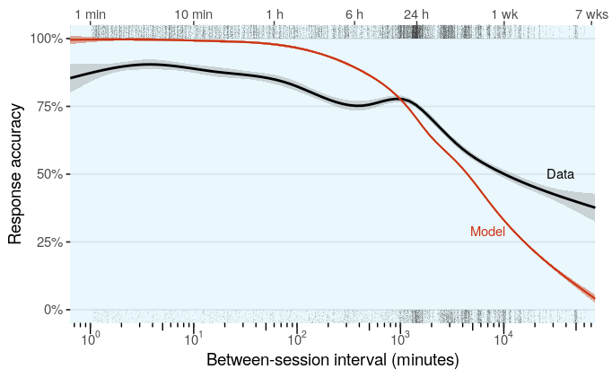

### Decay

We did not determine the decay directly, but derived it from the best-fitting activation. Across the whole data set, the best-fitting activation is -4.1130682. We determined the optimal decay for each item, such that it ended up at this activation. Since activation (and the threshold) are constant across the range, the predicted recall is also simply the best-fitting horizontal line through the data.

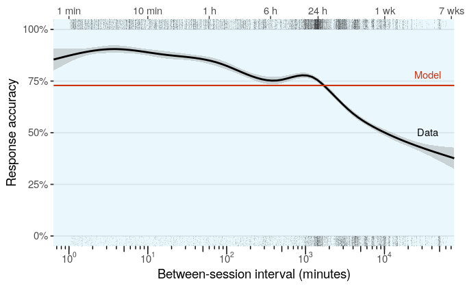

```r
pred_single_d <- predict_recall(d_seq_list_single,
                                decay = bs_d_indiv[n_windows == 1],
                                tau = lr_activation[n_windows == 1, tau])
d_single_d <- d_last[pred_single_d, on = .(id)]

p_single_d <- plot_comparison(d_model = d_single_d,
                              n_w = 1,
                              label_pos = list(data = list(x = 35000, y = .5),
                                               model = list(x = 35000, y = .78)))
```

### Scaling factor

Like the decay, the optimal scaling factor was derived from the best-fitting activation. In principle this should again produce a horizontal line. However, getting this activation value would require scaling by a factor larger than 1 for a large portion of the data. Since h is limited to 1, we cannot get the activation low enough in these cases, and so we overpredict retention.

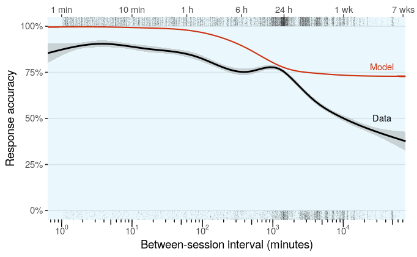

```r
pred_single_h <- predict_recall(d_seq_list_single,
                                h = bs_h_indiv[n_windows == 1],
                                tau = lr_activation[n_windows == 1, tau])
d_single_h <- d_last[pred_single_h, on = .(id)]

p_single_h <- plot_comparison(d_model = d_single_h,
                              n_w = 1,
                              label_pos = list(data = list(x = 35000, y = .5),
                                               model = list(x = 35000, y = .78)))
```

## 24-hour interval

Rather than determining the best parameter fit from the whole data set, we also explore a scenario in which we only have intervals around 24 hours, which is more similar to many controlled experiments.

We use a subset of the data with intervals around 24 hours. In the 20-window fit this falls quite neatly within window number 12, so we’ll use that.

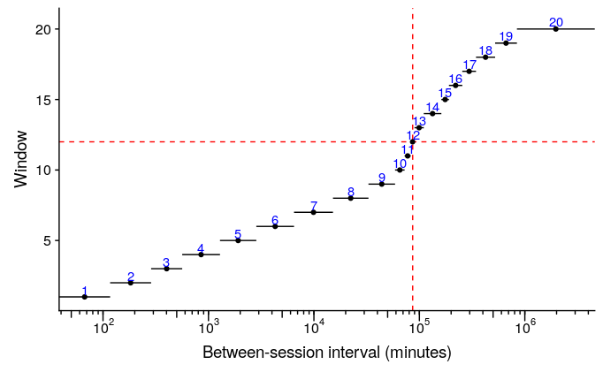

```r
ggplot(window_range[n_windows == 20]) +
  geom_vline(aes(xintercept = 24*60*60), colour = "red", lty = 2) +
  geom_hline(aes(yintercept = 12), colour = "red", lty = 2) +
  geom_segment(aes(x = start, xend = end, y = window, yend = window)) +
  geom_point(aes(x = geom_mean, y = window)) +
  geom_text(aes(x = geom_mean, y = window + .5, label = window), colour = "blue") +
  scale_x_log10(
    breaks = scales::trans_breaks("log10", function(x) 10^x),
    labels = scales::trans_format("log10", scales::math_format(10^.x)),
    expand = c(0, 0)
  ) +
  labs(x = "Between-session interval (minutes)",
       y = "Window") +
  annotation_logticks(sides = "b", outside = T) +
  coord_cartesian(clip = "off")
```

### Threshold

```r
tau_24h <- lr_tau[n_windows == 20 & window == 12, tau]
```

The optimal threshold for the 24h interval is -4.6927408, quite similar to the optimal threshold for the whole data set. The model’s predictions also look very similar.

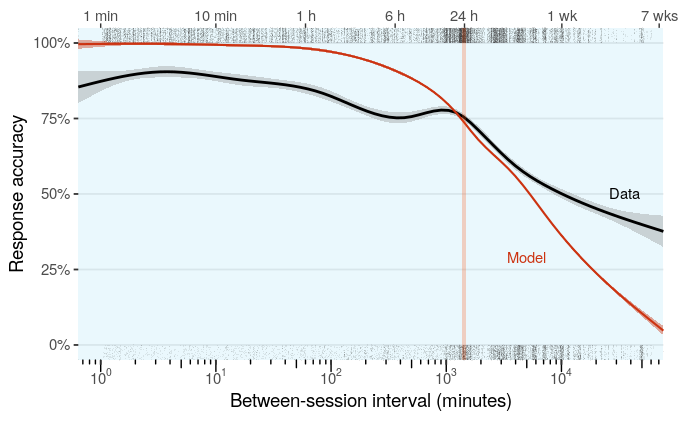

### Decay

Because optimal decay is derived separately for each individual learning sequence, there is not a single decay value associated with the 24h interval, and we only know the best decay for the individual sequences that fall within the 24h set.

```r
d_24h <- median(bs_d_indiv[n_windows == 20 & window == 12, d])
```

To get a parameter that we can use for general prediction, we’ll take the median: d = 0.3147813.

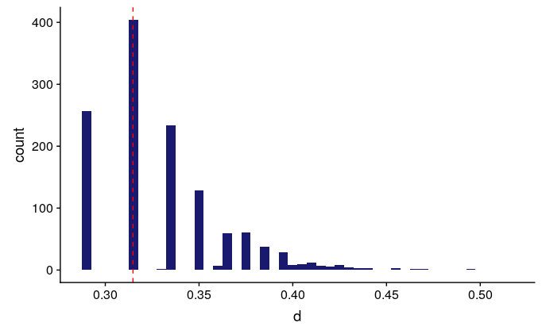

```r
ggplot(bs_d_indiv[n_windows == 20 & window == 12], aes(x = d)) +
  geom_histogram(binwidth = .005, fill = "midnightblue") +
  geom_vline(aes(xintercept = d_24h), colour = "red", lty = 2)
```

These predictions show the typical pattern: the model initially overpredicts recall, gets it right around 24h, and eventually underpredicts recall.

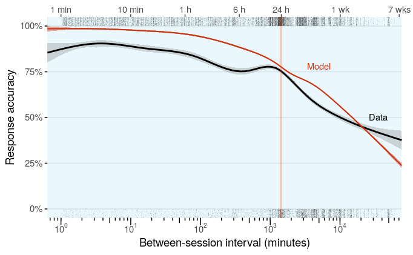

### Scaling factor

```r
h_24h <- median(bs_h_indiv[n_windows == 20 & window == 12, h])
```

As with decay, we’ll take the median scaling factor from the 24h set: h = 0.0116223.

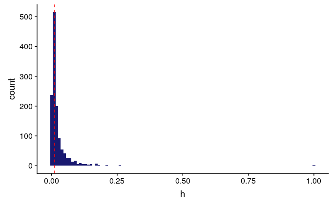

```r
ggplot(bs_h_indiv[n_windows == 20 & window == 12], aes(x = h)) +
  geom_histogram(binwidth = .01, fill = "midnightblue") +
  geom_vline(aes(xintercept = h_24h), colour = "red", lty = 2)
```

This model already does surprisingly well: short-term predictions are good, though the model is too optimistic on intervals of 1-24 hours, and too pessimistic on intervals longer than a week.

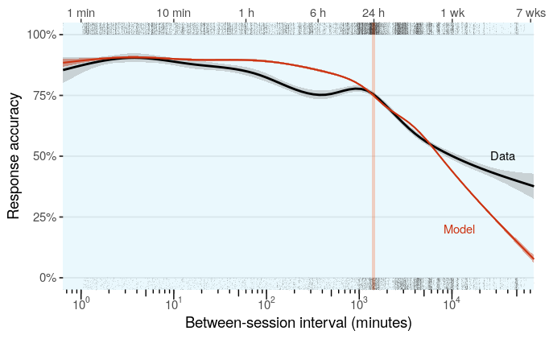

## Short intervals

### Threshold

Finally, we’ll look at a model with default parameters other than the threshold, which is fitted to short intervals (0-10 minutes) only.

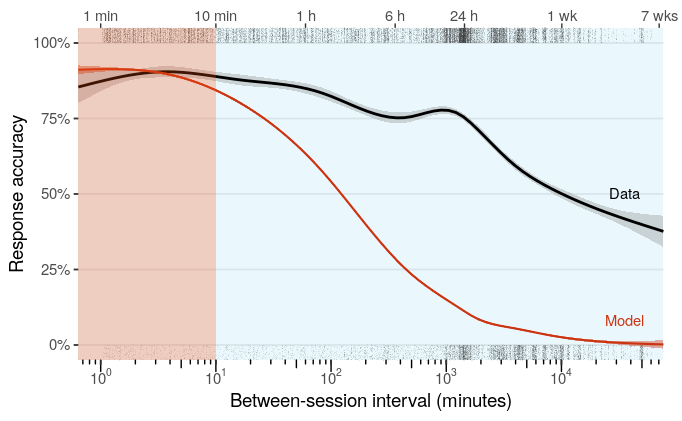

# Time-dependent parameters

Rather than using a single parameter configuration across the range, we can also fit parameters separately per time bin. Here we’ll look at the results when the data are split into 20 bins, each containing 5% of the total.

Prepare the data:

```r
d_20 <- copy(d_last)
d_20 <- d_20[, sequence := 1:.N][, .(id, sequence, time_between, window = ntile(time_between, 20))]
d_20_seq <- generate_seq_list(d_20[d_f, on = .(id)])
```

## Threshold

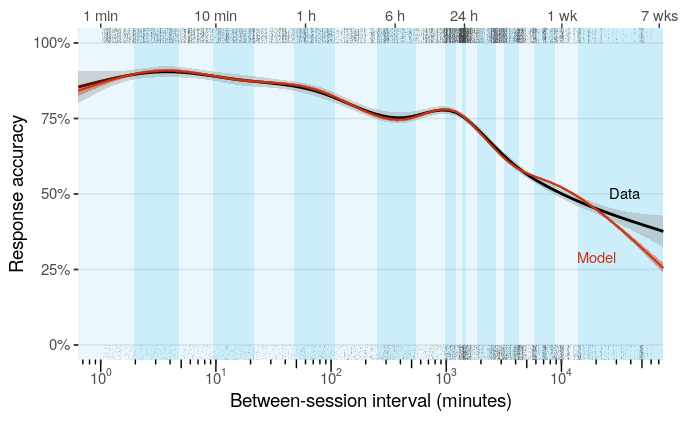

## Decay

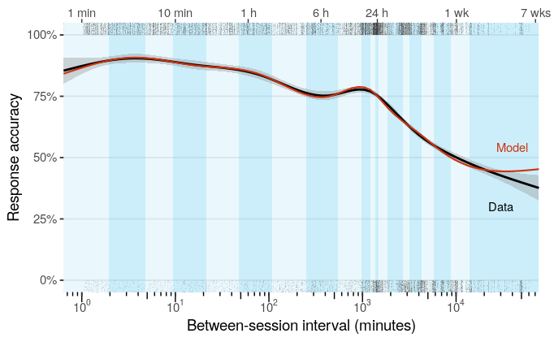

```r
pred_d_20 <- predict_recall(seq_list = d_20_seq,
                            decay = bs_d_indiv[n_windows == 20],
                            tau = lr_activation,
                            windows = 20)

d_d_20 <- d_last[pred_d_20, on = .(id)]

p_d_20 <- plot_comparison(d_model = d_d_20,
                          n_w = 20,
                          label_pos = list(data = list(x = 30000, y = .3),
                                           model = list(x = 40000, y = .54)))
```

## Scaling factor

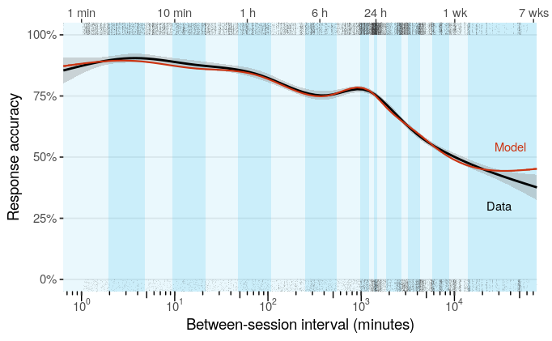

# Interval distribution

A histogram of the between-session intervals in the data.

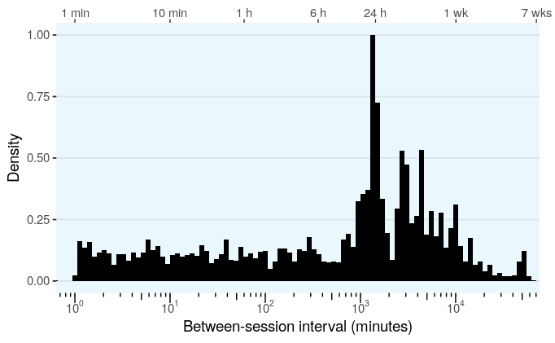

```r
p_histogram <- ggplot() +
  # Window background
  geom_rect(data = window_range[n_windows == 1], aes(xmin = start/60, xmax = end/60, ymin = -Inf, ymax = Inf), fill = window_col, alpha = .1) +
  # Time markers along the top
  geom_segment(aes(x = label_x, xend = label_x, y = 1.05, yend = 1.065), colour = "grey20") +
  geom_text(aes(x = label_x, y = label_y, label = label_txt), colour = "grey30") +
  # Histogram
  geom_histogram(data = d_last, aes(x = time_between/60, y = ..ncount..), bins = 100, fill = obs_col) +
  # Plot setup
  scale_x_log10(
    breaks = scales::trans_breaks("log10", function(x) 10^x),
    labels = scales::trans_format("log10", scales::math_format(10^.x)),
    expand = c(0, 0)
  ) +
  scale_y_continuous(breaks = seq(0, 1, by = .25)) +
  labs(x = "Between-session interval (minutes)",
       y = "Density") +
  annotation_logticks(sides = "b", outside = T) +
  coord_cartesian(ylim = c(0, 1), xlim = c(window_range[1, start], window_range[.N, end])/60, clip = "off") +
  theme_bw(base_size = 14) +
  theme(plot.margin = margin(21, 14, 7, 7),
        panel.grid.major.x = element_blank(),
        panel.grid.minor = element_blank(),
        panel.border = element_blank())

p_histogram
```

# Combined figure

[figure not shown]

```r
plot_grid(
  p_histogram,
  p_tau_short,
  p_tau_24h,
  p_tau_20,
  p_d_24h,
  p_d_20,
  p_h_24h,
  p_h_20,
  ncol = 2,
  labels = c("A\t\tInterval distribution", "B\t\tThreshold optimised for 0 - 10 min", "C\t\tThreshold optimised for 24h", "D\t\tInterval-dependent threshold", "E\t\tDecay optimised for 24h", "F\t\tInterval-dependent decay", "G\t\tScaling factor optimised for 24h", "H\t\tInterval-dependent scaling factor"),
  align = "hv",
  label_x = .025,
  hjust = 0,
  scale = .9
) +
  theme(plot.background = element_rect(fill = "white", colour = NA))

ggsave(file.path("..", "output", "model_fitting_results.png"), width = 10, height = 15)
```